# How to choose the optimal number of cluster

## Introduction

At the last coding dojo, the interrogation we get was the following: Is it possible to create a function which automatically define the optimal number of cluster? As usual, the answer with R is: there is a package to answer this question.

## Training data set

First, we generate some fake data: Not too much separated, but not too messy. It is a simulation, not real life :)

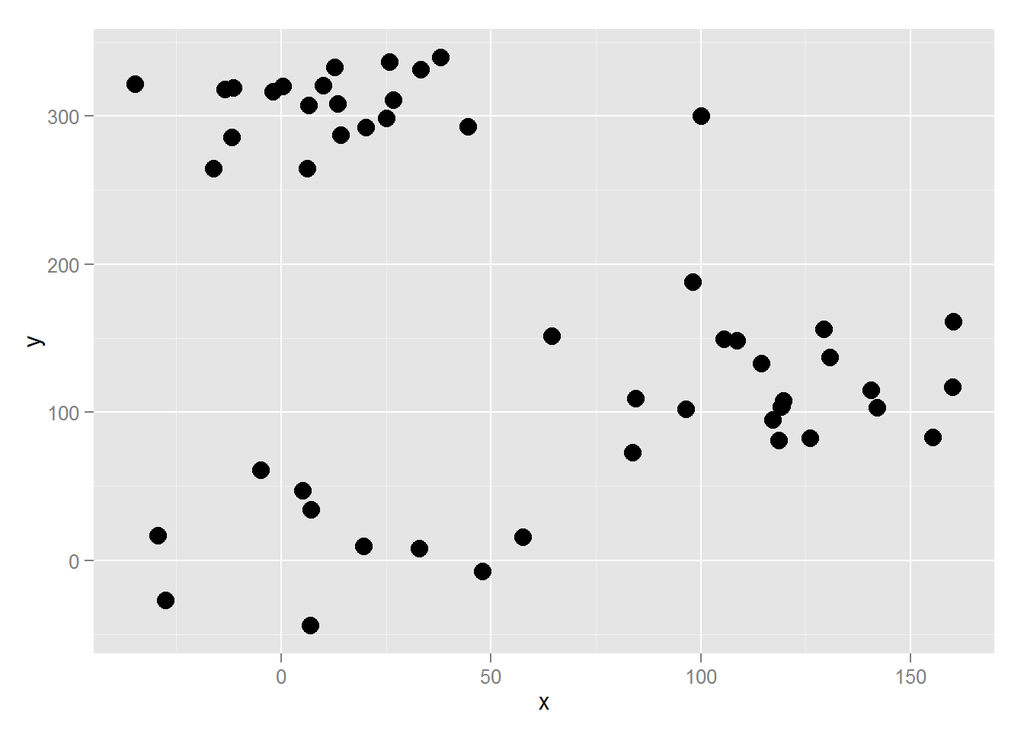

## Analysis

Our main inspiration is that post on stackoverflow:

http://stackoverflow.com/questions/15376075/cluster-analysis-in-r-determine-the-optimal-number-of-clusters

And the help of the Nbclust package.

The first way to determine a reasonnable number of cluster that I learn at school was the elbow plot. The concept is to plot the sum of the distance between the centroid of the cluster and the point of the cluster by cluster.

The plot looks like an elbow and the classic rule is to take the number of cluster where the curve begin to flaten. Afterward, each new cluster doesn’t create a really new separated cluster.

Elbow plot:

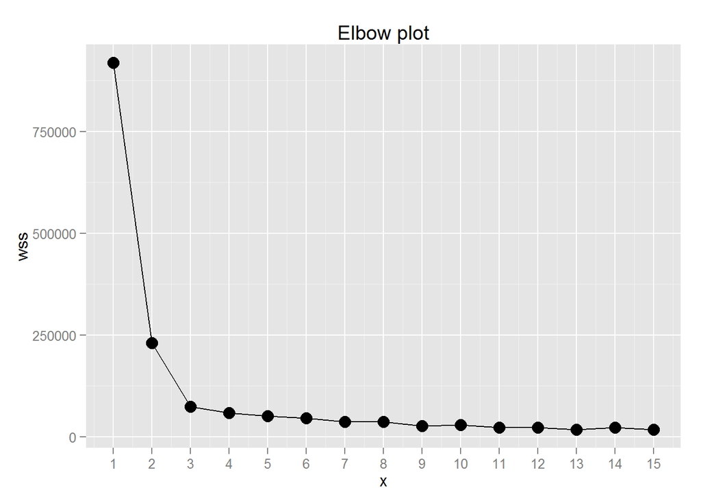

```r
wss <- (nrow(mat)-1)*sum(apply(mat[, -3],2,var))
  for (i in 2:15) wss[i] <- sum(kmeans(mat[, -3],
                                       centers=i)$withinss)

wss2 <- data.frame(x = 1:15, wss = wss)

ggplot(data = wss2, aes(x = x, y = wss))+
    geom_point(size = 4) +
  geom_line() +
  scale_x_continuous(breaks = 1:15) +
  ggtitle("Elbow plot")
```

The function NBClust:

This function test a consequent set of method to determine the optimal number of clusters.

```r
res <- NbClust(mat[, -3], diss=NULL, distance = "euclidean", min.nc=2, max.nc=6,
             method = "kmeans", index = "all")
```

The different method used (minus the graphical ones) and the number of clusters picked by each:

```r
res$Best.nc
```

```
##                     KL       CH Hartigan     CCC   Scott     Marriot
## Number_clusters  3.000   3.0000   3.0000  4.0000  3.0000           3
## Value_Index     19.257 281.3547  93.4184 15.3021 87.0884 17438536361
##                    TrCovW   TraceW Friedman   Rubin Cindex     DB
## Number_clusters         4      3.0   6.0000   3.000 2.0000 3.0000
## Value_Index     597723962 141127.6  45.3554 -15.136 0.3074 0.4639
##                 Silhouette   Duda PseudoT2  Beale Ratkowsky     Ball
## Number_clusters     3.0000 3.0000    3.000 3.0000    3.0000     3.00
## Value_Index         0.7129 0.6732    9.224 0.4612    0.5388 90476.02
##                 PtBiserial Frey McClain   Dunn Hubert SDindex Dindex
## Number_clusters     3.0000    1  2.0000 3.0000      0  3.0000      0
## Value_Index         0.8499   NA  0.3227 0.4573      0  0.0177      0
##                   SDbw
## Number_clusters 3.0000
## Value_Index     0.0716
```

Most common value:(Without 0)

```r
summary(res$Best.nc[1,][res$Best.nc[1,]!= 0])
```

```
##    Min. 1st Qu.  Median    Mean 3rd Qu.    Max.
##   1.000   3.000   3.000   3.042   3.000   6.000
```

In the end, the median of all this method is choose. In this case, 3.

## Result

The plot:

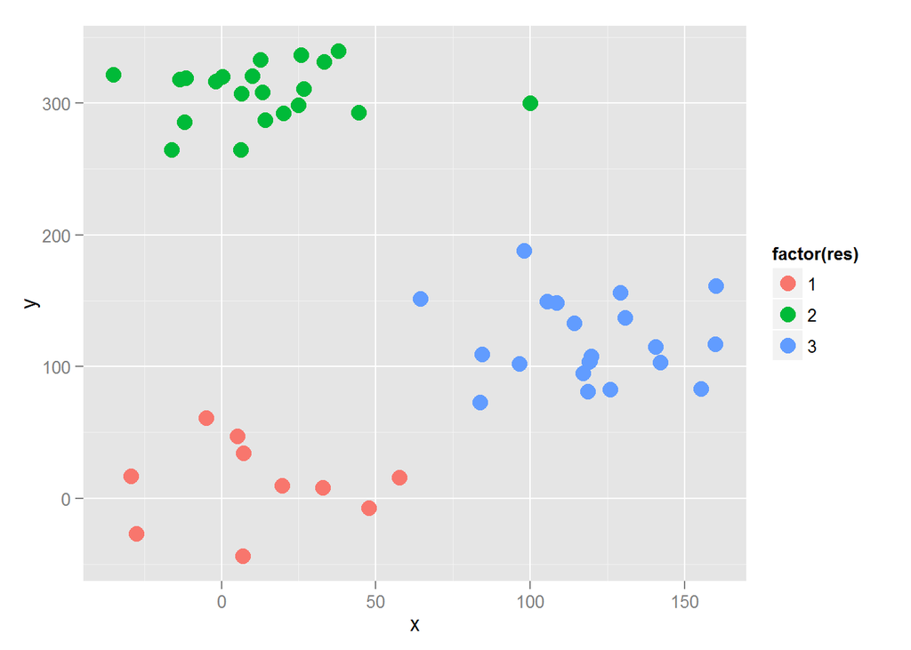

```r
mat$res <- res$Best.partition

ggplot(data = mat, aes(x = x, y = y, colour = factor(res))) +
    geom_point( size = 4)
```

There is another approach we didn’t had time to look, but which seems promising: The package BHC which does bayesian hierarchical clustering could also provide us an insight on the best cluster.